```python
import pandas as pd
import numpy as np
import matplotlib.pyplot as plt
import seaborn as sns
import warnings
warnings.filterwarnings('ignore')
%matplotlib inline

pd.set_option('display.max_columns', 50)
```

```python
data = pd.read_csv('EmployeeData.csv')
```

# Exploratory Data Analysis

```python
data.head()
```

|  | Age | Attrition | BusinessTravel | DailyRate | Department | DistanceFromHome | Education | EducationField | EmployeeCount | EmployeeNumber | EnvironmentSatisfaction | Gender | HourlyRate | JobInvolvement | JobLevel | JobRole | JobSatisfaction | MaritalStatus | MonthlyIncome | MonthlyRate | NumCompaniesWorked | Over18 | OverTime | PercentSalaryHike | PerformanceRating | RelationshipSatisfaction | StandardHours | StockOptionLevel | TotalWorkingYears | … |
| --- | --- | --- | --- | --- | --- | --- | --- | --- | --- | --- | --- | --- | --- | --- | --- | --- | --- | --- | --- | --- | --- | --- | --- | --- | --- | --- | --- | --- | --- | --- |
| 0 | 41 | 1 | Travel_Rarely | 1102 | Sales | 1 | 2 | Life Sciences | 1 | 1 | 2 | Female | 94 | 3 | 2 | Sales Executive | 4 | Single | 5993 | 19479 | 8 | Y | Yes | 11 | 3 | 1 | 80 | 0 | 8 | … |
| 1 | 49 | 0 | Travel_Frequently | 279 | Research & Development | 8 | 1 | Life Sciences | 1 | 2 | 3 | Male | 61 | 2 | 2 | Research Scientist | 2 | Married | 5130 | 24907 | 1 | Y | No | 23 | 4 | 4 | 80 | 1 | 10 | … |
| 2 | 37 | 1 | Travel_Rarely | 1373 | Research & Development | 2 | 2 | Other | 1 | 4 | 4 | Male | 92 | 2 | 1 | Laboratory Technician | 3 | Single | 2090 | 2396 | 6 | Y | Yes | 15 | 3 | 2 | 80 | 0 | 7 | … |
| 3 | 33 | 0 | Travel_Frequently | 1392 | Research & Development | 3 | 4 | Life Sciences | 1 | 5 | 4 | Female | 56 | 3 | 1 | Research Scientist | 3 | Married | 2909 | 23159 | 1 | Y | Yes | 11 | 3 | 3 | 80 | 0 | 8 | … |
| 4 | 27 | 0 | Travel_Rarely | 591 | Research & Development | 2 | 1 | Medical | 1 | 7 | 1 | Male | 40 | 3 | 1 | Laboratory Technician | 2 | Married | 3468 | 16632 | 9 | Y | No | 12 | 3 | 4 | 80 | 1 | 6 | … |

```python
data.shape
```

```
(1470, 35)
```

```python
data.columns
```

```
Index(['Age', 'Attrition', 'BusinessTravel', 'DailyRate', 'Department',
       'DistanceFromHome', 'Education', 'EducationField', 'EmployeeCount',
       'EmployeeNumber', 'EnvironmentSatisfaction', 'Gender', 'HourlyRate',
       'JobInvolvement', 'JobLevel', 'JobRole', 'JobSatisfaction',
       'MaritalStatus', 'MonthlyIncome', 'MonthlyRate', 'NumCompaniesWorked',
       'Over18', 'OverTime', 'PercentSalaryHike', 'PerformanceRating',
       'RelationshipSatisfaction', 'StandardHours', 'StockOptionLevel',
       'TotalWorkingYears', 'TrainingTimesLastYear', 'WorkLifeBalance',
       'YearsAtCompany', 'YearsInCurrentRole', 'YearsSinceLastPromotion',
       'YearsWithCurrManager'],
      dtype='object')
```

```python
data.describe().T
```

|  | count | mean | std | min | 25% | 50% | 75% | max |
| --- | --- | --- | --- | --- | --- | --- | --- | --- |
| Age | 1470.0 | 36.923810 | 9.135373 | 18.0 | 30.00 | 36.0 | 43.00 | 60.0 |
| Attrition | 1470.0 | 0.161224 | 0.367863 | 0.0 | 0.00 | 0.0 | 0.00 | 1.0 |
| DailyRate | 1470.0 | 802.485714 | 403.509100 | 102.0 | 465.00 | 802.0 | 1157.00 | 1499.0 |
| DistanceFromHome | 1470.0 | 9.192517 | 8.106864 | 1.0 | 2.00 | 7.0 | 14.00 | 29.0 |
| Education | 1470.0 | 2.912925 | 1.024165 | 1.0 | 2.00 | 3.0 | 4.00 | 5.0 |
| EmployeeCount | 1470.0 | 1.000000 | 0.000000 | 1.0 | 1.00 | 1.0 | 1.00 | 1.0 |
| EmployeeNumber | 1470.0 | 1024.865306 | 602.024335 | 1.0 | 491.25 | 1020.5 | 1555.75 | 2068.0 |
| EnvironmentSatisfaction | 1470.0 | 2.721769 | 1.093082 | 1.0 | 2.00 | 3.0 | 4.00 | 4.0 |
| HourlyRate | 1470.0 | 65.891156 | 20.329428 | 30.0 | 48.00 | 66.0 | 83.75 | 100.0 |
| JobInvolvement | 1470.0 | 2.729932 | 0.711561 | 1.0 | 2.00 | 3.0 | 3.00 | 4.0 |
| JobLevel | 1470.0 | 2.063946 | 1.106940 | 1.0 | 1.00 | 2.0 | 3.00 | 5.0 |
| JobSatisfaction | 1470.0 | 2.728571 | 1.102846 | 1.0 | 2.00 | 3.0 | 4.00 | 4.0 |
| MonthlyIncome | 1470.0 | 6502.931293 | 4707.956783 | 1009.0 | 2911.00 | 4919.0 | 8379.00 | 19999.0 |
| MonthlyRate | 1470.0 | 14313.103401 | 7117.786044 | 2094.0 | 8047.00 | 14235.5 | 20461.50 | 26999.0 |
| NumCompaniesWorked | 1470.0 | 2.693197 | 2.498009 | 0.0 | 1.00 | 2.0 | 4.00 | 9.0 |
| PercentSalaryHike | 1470.0 | 15.209524 | 3.659938 | 11.0 | 12.00 | 14.0 | 18.00 | 25.0 |
| PerformanceRating | 1470.0 | 3.153741 | 0.360824 | 3.0 | 3.00 | 3.0 | 3.00 | 4.0 |
| RelationshipSatisfaction | 1470.0 | 2.712245 | 1.081209 | 1.0 | 2.00 | 3.0 | 4.00 | 4.0 |
| StandardHours | 1470.0 | 80.000000 | 0.000000 | 80.0 | 80.00 | 80.0 | 80.00 | 80.0 |
| StockOptionLevel | 1470.0 | 0.793878 | 0.852077 | 0.0 | 0.00 | 1.0 | 1.00 | 3.0 |
| TotalWorkingYears | 1470.0 | 11.279592 | 7.780782 | 0.0 | 6.00 | 10.0 | 15.00 | 40.0 |
| TrainingTimesLastYear | 1470.0 | 2.799320 | 1.289271 | 0.0 | 2.00 | 3.0 | 3.00 | 6.0 |
| WorkLifeBalance | 1470.0 | 2.761224 | 0.706476 | 1.0 | 2.00 | 3.0 | 3.00 | 4.0 |
| YearsAtCompany | 1470.0 | 7.008163 | 6.126525 | 0.0 | 3.00 | 5.0 | 9.00 | 40.0 |
| YearsInCurrentRole | 1470.0 | 4.229252 | 3.623137 | 0.0 | 2.00 | 3.0 | 7.00 | 18.0 |
| YearsSinceLastPromotion | 1470.0 | 2.187755 | 3.222430 | 0.0 | 0.00 | 1.0 | 3.00 | 15.0 |
| YearsWithCurrManager | 1470.0 | 4.123129 | 3.568136 | 0.0 | 2.00 | 3.0 | 7.00 | 17.0 |

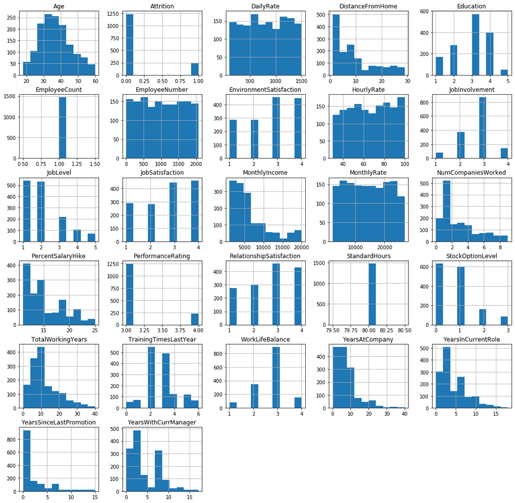

```python
# data distribution of Numerical columns
data.hist(figsize = (18,18))
plt.show()
```

**From above graph we infer that:**

- **Non-Useful Data:** EmployeeCount & StandardHours are constant values and EmployeeNumber is simply a unique identifier. They are of no use for modeling purposes.
- **Non-Normal Distributions:** Many of the variables are skewed to the right such as MonthlyIncome, JobLevel, and DistanceFromHome. Transform these columns to a normal distribution for modeling purposes.

## Target Variable

**Attrition** columm is our **Target variable**

- it has two classes 0 and 1.

```
0    1233
1     237
Name: Attrition, dtype: int64
Percentage of Current Employees = 83.9%
Percentage of Former Employees = 16.1%
```

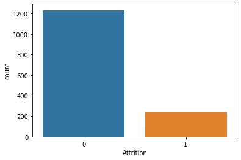

```python
#Checking whether data set is balanced or imbalanced
print(data['Attrition'].value_counts())
sns.countplot(data['Attrition']);

# Attrition distribution
print("Percentage of Current Employees = {:.1f}%".format(
    data[data['Attrition'] == 0].shape[0] / data.shape[0]*100))

print("Percentage of Former Employees = {:.1f}%".format(
    data[data['Attrition'] == 1].shape[0] / data.shape[0]*100))
```

**From above plot we can infer that:**

- The data set is imbalanced.
- Employees that have left the company is about 16%.

```python
# check the datatypes
data.dtypes
```

```
Age                          int64
Attrition                    int64
BusinessTravel              object
DailyRate                    int64
Department                  object
DistanceFromHome             int64
Education                    int64
EducationField              object
EmployeeCount                int64
EmployeeNumber               int64
EnvironmentSatisfaction      int64
Gender                      object
HourlyRate                   int64
JobInvolvement               int64
JobLevel                     int64
JobRole                     object
JobSatisfaction              int64
MaritalStatus               object
MonthlyIncome                int64
MonthlyRate                  int64
NumCompaniesWorked           int64
Over18                      object
OverTime                    object
PercentSalaryHike            int64
PerformanceRating            int64
RelationshipSatisfaction     int64
StandardHours                int64
StockOptionLevel             int64
TotalWorkingYears            int64
TrainingTimesLastYear        int64
WorkLifeBalance              int64
YearsAtCompany               int64
YearsInCurrentRole           int64
YearsSinceLastPromotion      int64
YearsWithCurrManager         int64
dtype: object
```

```python
# check for any missing value
data.isnull().sum()
```

```
Age                         0
Attrition                   0
BusinessTravel              0
DailyRate                   0
Department                  0
DistanceFromHome            0
Education                   0
EducationField              0
EmployeeCount               0
EmployeeNumber              0
EnvironmentSatisfaction     0
Gender                      0
HourlyRate                  0
JobInvolvement              0
JobLevel                    0
JobRole                     0
JobSatisfaction             0
MaritalStatus               0
MonthlyIncome               0
MonthlyRate                 0
NumCompaniesWorked          0
Over18                      0
OverTime                    0
PercentSalaryHike           0
PerformanceRating           0
RelationshipSatisfaction    0
StandardHours               0
StockOptionLevel            0
TotalWorkingYears           0
TrainingTimesLastYear       0
WorkLifeBalance             0
YearsAtCompany              0
YearsInCurrentRole          0
YearsSinceLastPromotion     0
YearsWithCurrManager        0
dtype: int64
```

```python
# check for any duplicate rows
data.duplicated().sum()
```

```
0
```

## 'Age' feature

```python
#Grouping data with respect to age
age=pd.DataFrame(data.groupby("Age")[["MonthlyIncome","Education","JobLevel","JobInvolvement","PerformanceRating","JobSatisfaction","EnvironmentSatisfaction","RelationshipSatisfaction","WorkLifeBalance","DailyRate","MonthlyRate"]].mean())
age["Count"]=data.Age.value_counts(dropna=False)
age.reset_index(level=0, inplace=True)
age.head()
```

|  | Age | MonthlyIncome | Education | JobLevel | JobInvolvement | PerformanceRating | JobSatisfaction | EnvironmentSatisfaction | RelationshipSatisfaction | WorkLifeBalance | DailyRate | MonthlyRate | Count |
| --- | --- | --- | --- | --- | --- | --- | --- | --- | --- | --- | --- | --- | --- |
| 0 | 18 | 1518.375000 | 2.500000 | 1.000 | 2.875000 | 3.000000 | 3.250000 | 2.750000 | 3.125000 | 3.000000 | 747.625000 | 14476.000000 | 8 |
| 1 | 19 | 2075.000000 | 2.111111 | 1.000 | 2.444444 | 3.444444 | 2.555556 | 2.444444 | 2.888889 | 3.222222 | 548.444444 | 15119.666667 | 9 |
| 2 | 20 | 2539.363636 | 2.636364 | 1.000 | 2.636364 | 3.000000 | 2.636364 | 3.181818 | 2.363636 | 2.909091 | 819.454545 | 16480.909091 | 11 |
| 3 | 21 | 2491.461538 | 1.615385 | 1.000 | 2.692308 | 3.153846 | 2.692308 | 2.692308 | 2.692308 | 2.769231 | 762.846154 | 17268.923077 | 13 |
| 4 | 22 | 2950.000000 | 1.812500 | 1.125 | 2.750000 | 3.250000 | 2.937500 | 2.812500 | 2.250000 | 2.750000 | 806.937500 | 14424.125000 | 16 |

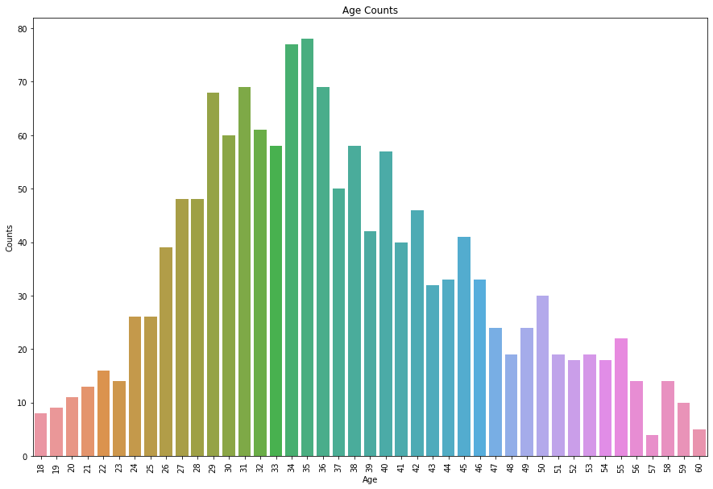

```python
plt.figure(figsize=(15,10))
ax=sns.barplot(x=age.Age,y=age.Count)
plt.xticks(rotation=90)
plt.xlabel("Age")
plt.ylabel("Counts")
plt.title("Age Counts")
plt.show()
```

**Maximum number of people working is of age 35**

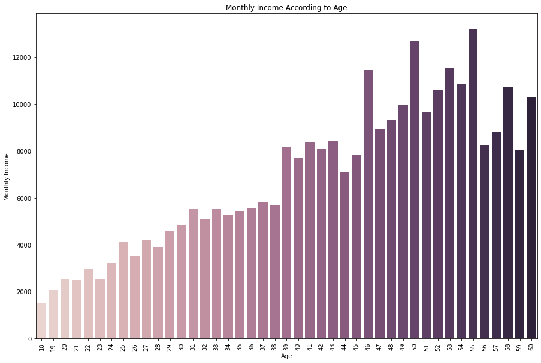

```python
plt.figure(figsize=(15,10))
ax=sns.barplot(x=age.Age,y=age.MonthlyIncome,palette = sns.cubehelix_palette(len(age.index)))
plt.xticks(rotation=90)
plt.xlabel("Age")
plt.ylabel("Monthly Income")
plt.title("Monthly Income According to Age")
plt.show()
```

**Highest monthly income belong to the people of age 55**

```python
# creating age categories
def age(x):
    if x < 25:
        return 'Under 25'
    elif 25 <= x < 35:
        return '25-34'
    elif 35 <= x < 45:
        return '35-44'
    else:
        return '45-60'
```

```python
# apply above function to all the rows of 'Age' column
data['Age_group'] = data['Age'].apply(lambda x: age(x))
```

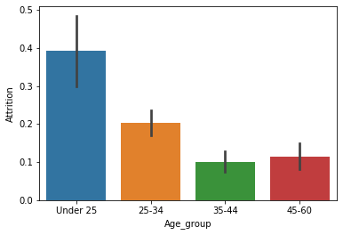

```python
sns.barplot(x= 'Age_group', y = 'Attrition', data = data, order = ['Under 25', '25-34','35-44','45-60'])
```

Employees 'Under age 25' have highest attrition as compare to other age groups.

## 'Business Travel' feature

```python
data['BusinessTravel'].value_counts()
```

```
Travel_Rarely        1043
Travel_Frequently     277
Non-Travel            150
Name: BusinessTravel, dtype: int64
```

```python
data.groupby('BusinessTravel')['Attrition'].agg(['mean','count'])
```

| BusinessTravel | mean | count |
| --- | --- | --- |
| Non-Travel | 0.080000 | 150 |
| Travel_Frequently | 0.249097 | 277 |
| Travel_Rarely | 0.149569 | 1043 |

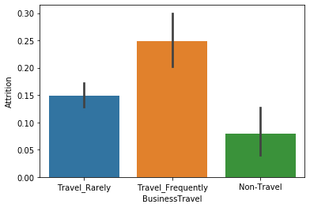

```python
sns.barplot(x = 'BusinessTravel', y = 'Attrition', data = data)
```

Employee who **Travel Frequently** have higher Attrition as compare to employee who **Travel Rarely** or **Not Travel**.

## 'Department' feature

```python
data['Department'].value_counts()
```

```
Research & Development    961
Sales                     446
Human Resources            63
Name: Department, dtype: int64
```

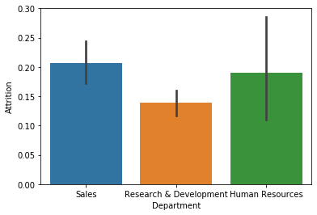

```python
sns.barplot(x= 'Department', y = 'Attrition', data = data)
```

Sales and Human Resources Department employee have high Attrition

## 'DistanceFromHome' feature

```python
data['DistanceFromHome'].value_counts().head()
```

```
2     211
1     208
10     86
9      85
3      84
Name: DistanceFromHome, dtype: int64
```

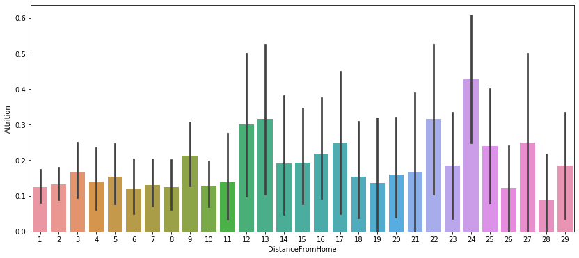

```python
plt.figure(figsize = (14,6))
sns.barplot(x= 'DistanceFromHome', y = 'Attrition', data = data)
```

Generally Employees who have greater distance from home to office have higher attrition.

## 'Education' and 'EducationField' feature

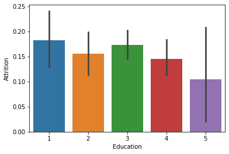

```python
sns.barplot(x = 'Education', y= 'Attrition', data = data)
```

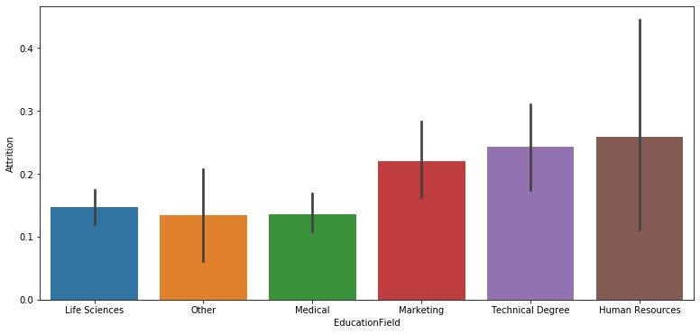

```python
plt.figure(figsize = (13,6))
sns.barplot(x = 'EducationField', y= 'Attrition', data = data)
```

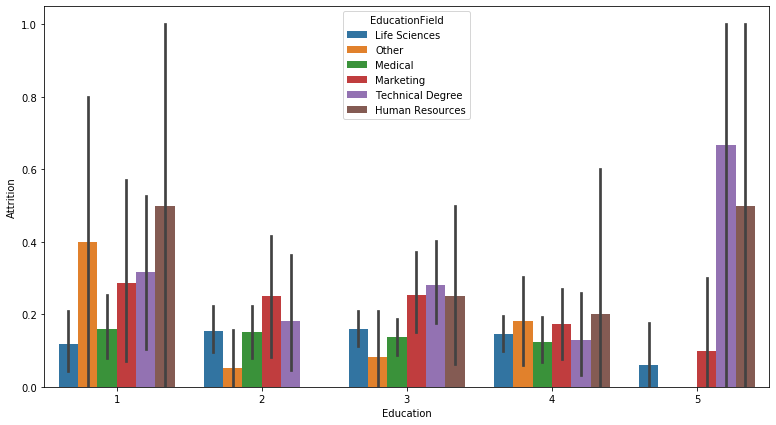

```python
plt.figure(figsize = (13,7))
sns.barplot(x = 'Education', y= 'Attrition', hue = 'EducationField', data = data)
```

Employee having eduction level 5 and education in Technical Degree have highest avg. attrition of about 0.7

## 'Gender' and 'Marital Status' feature

```python
data['Gender'].value_counts()
```

```
Male      882
Female    588
Name: Gender, dtype: int64
```

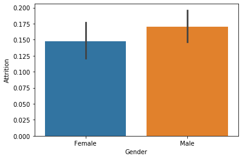

```python
sns.barplot(x = 'Gender', y = 'Attrition', data = data)
```

```python
data['MaritalStatus'].value_counts()
```

```
Married     673
Single      470
Divorced    327
Name: MaritalStatus, dtype: int64
```

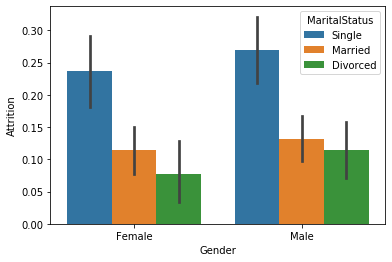

```python
sns.barplot(x = 'Gender', y = 'Attrition',hue = 'MaritalStatus', data = data)
```

## 'Job Level' feature

```python
data['JobLevel'].value_counts()
```

```
1    543
2    534
3    218
4    106
5     69
Name: JobLevel, dtype: int64
```

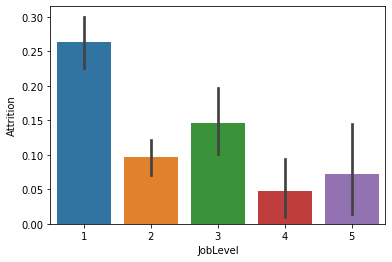

```python
sns.barplot(x = 'JobLevel', y = 'Attrition', data = data)
```

## 'Job Role' feature

```python
# Attrition by Department
#Grouping Data with respect to Department , JobRole and Attrition
grouped = data.groupby(["Department","JobRole","Attrition"])
output = pd.DataFrame()
output['n'] = grouped["Attrition"].count()
# Creating column for percentage of people left and not left in each department and job roles.
output['pct'] = output['n'].groupby("JobRole").transform(lambda x: x/x.sum())
# Reset index
output = output.reset_index()
# Change decimal to integer for readability
output['pct'] = output['pct'] * 100
# Add column with combined dept & job role
output['Dept_jobrole'] = output['Department'].str.cat(output[['JobRole']], sep=' : ')

output
```

|  | Department | JobRole | Attrition | n | pct | Dept_jobrole |
| --- | --- | --- | --- | --- | --- | --- |
| 0 | Human Resources | Human Resources | 0 | 40 | 76.923077 | Human Resources : Human Resources |
| 1 | Human Resources | Human Resources | 1 | 12 | 23.076923 | Human Resources : Human Resources |
| 2 | Human Resources | Manager | 0 | 11 | 10.784314 | Human Resources : Manager |
| 3 | Research & Development | Healthcare Representative | 0 | 122 | 93.129771 | Research & Development : Healthcare Representa... |
| 4 | Research & Development | Healthcare Representative | 1 | 9 | 6.870229 | Research & Development : Healthcare Representa... |
| 5 | Research & Development | Laboratory Technician | 0 | 197 | 76.061776 | Research & Development : Laboratory Technician |
| 6 | Research & Development | Laboratory Technician | 1 | 62 | 23.938224 | Research & Development : Laboratory Technician |
| 7 | Research & Development | Manager | 0 | 51 | 50.000000 | Research & Development : Manager |
| 8 | Research & Development | Manager | 1 | 3 | 2.941176 | Research & Development : Manager |
| 9 | Research & Development | Manufacturing Director | 0 | 135 | 93.103448 | Research & Development : Manufacturing Director |
| 10 | Research & Development | Manufacturing Director | 1 | 10 | 6.896552 | Research & Development : Manufacturing Director |
| 11 | Research & Development | Research Director | 0 | 78 | 97.500000 | Research & Development : Research Director |
| 12 | Research & Development | Research Director | 1 | 2 | 2.500000 | Research & Development : Research Director |
| 13 | Research & Development | Research Scientist | 0 | 245 | 83.904110 | Research & Development : Research Scientist |
| 14 | Research & Development | Research Scientist | 1 | 47 | 16.095890 | Research & Development : Research Scientist |
| 15 | Sales | Manager | 0 | 35 | 34.313725 | Sales : Manager |
| 16 | Sales | Manager | 1 | 2 | 1.960784 | Sales : Manager |
| 17 | Sales | Sales Executive | 0 | 269 | 82.515337 | Sales : Sales Executive |
| 18 | Sales | Sales Executive | 1 | 57 | 17.484663 | Sales : Sales Executive |
| 19 | Sales | Sales Representative | 0 | 50 | 60.240964 | Sales : Sales Representative |
| 20 | Sales | Sales Representative | 1 | 33 | 39.759036 | Sales : Sales Representative |

### Job roles that have the highest number of attrition in each department

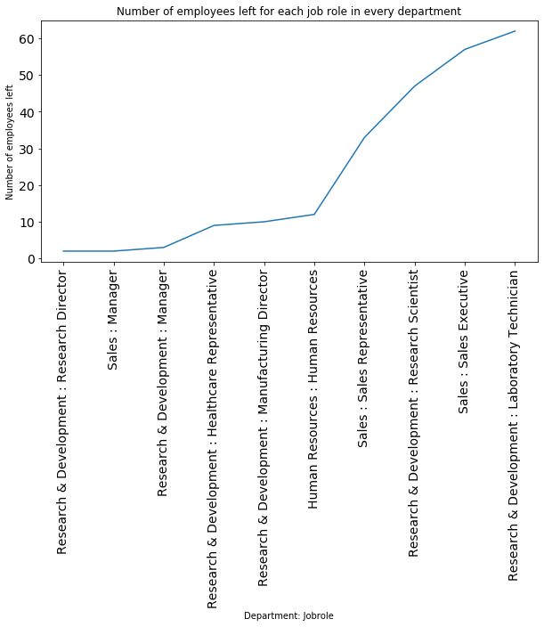

```python
# Filter for only employees who have left
output_yes = output[output["Attrition"] == 1]

# Filter for only employees who have did not left
output_no = output[output["Attrition"] == 0]


# Sort in ascending order for plotting
output_yes = output_yes.sort_values('n', ascending=True)
output_no = output_no.sort_values('n', ascending=True)


plt.figure(figsize=(10,5))
plt.tick_params(labelsize=14)
plt.plot( output_yes.Dept_jobrole, output_yes.n)
plt.xlabel('Department: Jobrole')
plt.ylabel('Number of employees left')
plt.title('Number of employees left for each job role in every department')
plt.xticks(rotation='vertical')
plt.show()


#plt.figure(figsize=(10,5))
#plt.tick_params(labelsize=14)
#plt.plot( output_no.Dept_jobrole, output_no.n)
#plt.xlabel('Department: Jobrole')
#plt.ylabel('Number of employees did not leave')
#plt.title('Number of employees did not leave for each job role in every department')
#plt.xticks(rotation='vertical')
#plt.show()
```

### Job roles having the highest attrition by percent

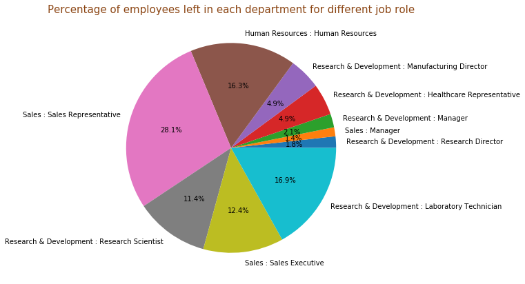

```python
# Plotting pie chart for percentage of employess left and did not leave in different department for different job roles.
labels=output_yes.Dept_jobrole
sizes=output_yes.pct
plt.figure(figsize=(7,7))
plt.pie(sizes,labels=labels,autopct="%1.1f%%")
plt.title("Percentage of employees left in each department for different job role",color="saddlebrown",fontsize=15)

#labels=output_no.Dept_jobrole
#sizes=output_no.pct
#plt.figure(figsize=(7,7))
#plt.pie(sizes,labels=labels,autopct="%1.1f%%")
#plt.title("Percentage of employees did not leave in each department for different job role",color="saddlebrown",fontsize=15)
```

## 'Monthly income' feature

```python
#Getting insight of different salaries variation with respect to job role
income=pd.DataFrame(data.groupby("JobRole")['MonthlyIncome'].mean().sort_values(ascending=False))
income
```

| JobRole | MonthlyIncome |
| --- | --- |
| Manager | 17181.676471 |
| Research Director | 16033.550000 |
| Healthcare Representative | 7528.763359 |
| Manufacturing Director | 7295.137931 |
| Sales Executive | 6924.279141 |
| Human Resources | 4235.750000 |
| Research Scientist | 3239.972603 |
| Laboratory Technician | 3237.169884 |
| Sales Representative | 2626.000000 |

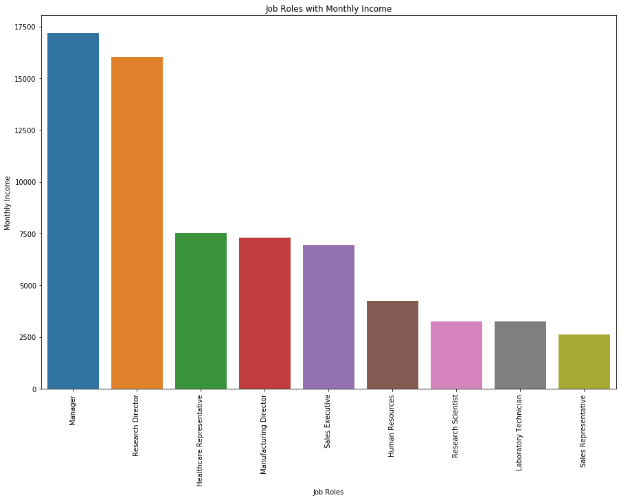

```python
#Plotting job roles with monthly income
plt.figure(figsize=(15,10))
ax=sns.barplot(x=income.index,y=income.MonthlyIncome)
plt.xticks(rotation=90)
plt.xlabel("Job Roles")
plt.ylabel("Monthly Income")
plt.title("Job Roles with Monthly Income")
plt.show()
```

**Managers have highest Monthly Income and Sales representatives have least monthly income**

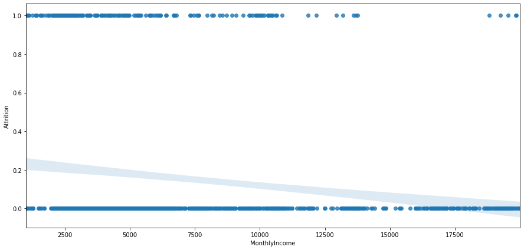

```python
plt.figure(figsize = (15,7))
sns.regplot(x = 'MonthlyIncome', y = 'Attrition', data = data)
```

**Employee with less Monthly income have more attrition**

## 'Over Time' feature

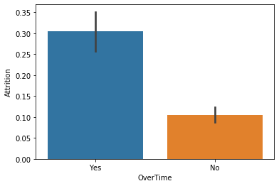

```python
sns.barplot(x = 'OverTime', y = 'Attrition', data = data)
```

## 'YearsSinceLastPromotion' feature

```python
data['YearsSinceLastPromotion'].value_counts()
```

```
0     581
1     357
2     159
7      76
4      61
3      52
5      45
6      32
11     24
8      18
9      17
15     13
13     10
12     10
14      9
10      6
Name: YearsSinceLastPromotion, dtype: int64
```

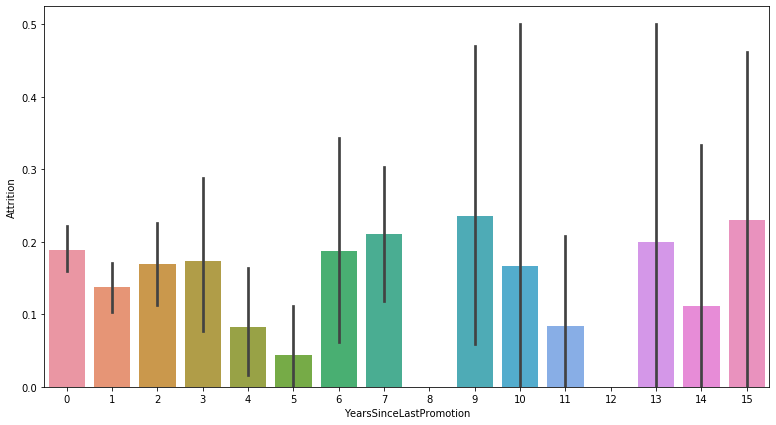

```python
plt.figure(figsize = (13,7))
sns.barplot(x ='YearsSinceLastPromotion' , y = 'Attrition', data = data)
```

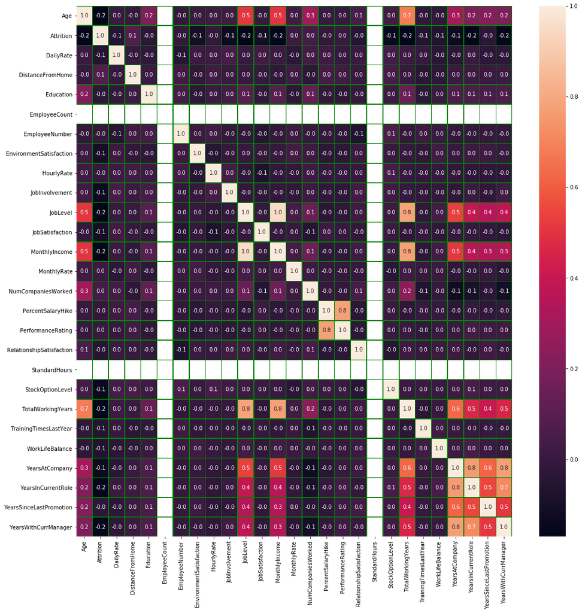

```python
# check the correlation
f,ax=plt.subplots(figsize=(18,18))
sns.heatmap(data.corr(),annot=True,linewidths=0.5,linecolor="green",fmt=".1f",ax=ax)
plt.show()
```

**Analysis from correlation**

- Monthly income is highly correlated with Job level.
- Job level is highly correlated with total working years.
- Monthly income is highly correlated with total working years.
- Age is also positively correlated with the Total working years.

**Conclusions:**

- The workers with low JobLevel,monthly income likely to quit then other employees.
- BusinessTravel : The workers who travel alot are more likely to quit then other employees.
- Department : The worker in R&D are more likely to stay then the workers on other departement.
- EducationField : The workers with Human Resources and Technical Degree are more likely to quit then employees from other fields of educations.
- Gender : The Male are more likely to quit.
- JobRole : The workers in Laboratory Technician, Sales Representative, and Human Resources are more likely to quit the workers in other positions.
- MaritalStatus : The workers who have Single marital status are more likely to quit the Married, and Divorced.
- OverTime : The workers who work more hours are likely to quit then others

# Data Preprocessing

```python
# drop some irrelevent columns
cols = ['EmployeeNumber','EmployeeCount','Over18','MonthlyIncome','StandardHours','Age_group']
```

```python
data.drop(cols, axis =1, inplace = True)
```

```python
data.columns
```

```
Index(['Age', 'Attrition', 'BusinessTravel', 'DailyRate', 'Department',
       'DistanceFromHome', 'Education', 'EducationField',
       'EnvironmentSatisfaction', 'Gender', 'HourlyRate', 'JobInvolvement',
       'JobLevel', 'JobRole', 'JobSatisfaction', 'MaritalStatus',
       'MonthlyRate', 'NumCompaniesWorked', 'OverTime', 'PercentSalaryHike',
       'PerformanceRating', 'RelationshipSatisfaction', 'StockOptionLevel',
       'TotalWorkingYears', 'TrainingTimesLastYear', 'WorkLifeBalance',
       'YearsAtCompany', 'YearsInCurrentRole', 'YearsSinceLastPromotion',
       'YearsWithCurrManager'],
      dtype='object')
```

```python
data.shape
```

```
(1470, 30)
```

```python
data.head()
```

|  | Age | Attrition | BusinessTravel | DailyRate | Department | DistanceFromHome | Education | EducationField | EnvironmentSatisfaction | Gender | HourlyRate | JobInvolvement | JobLevel | JobRole | JobSatisfaction | MaritalStatus | MonthlyRate | NumCompaniesWorked | OverTime | PercentSalaryHike | PerformanceRating | RelationshipSatisfaction | StockOptionLevel | TotalWorkingYears | TrainingTimesLastYear | WorkLifeBalance | YearsAtCompany | YearsInCurrentRole | YearsSinceLastPromotion | … |
| --- | --- | --- | --- | --- | --- | --- | --- | --- | --- | --- | --- | --- | --- | --- | --- | --- | --- | --- | --- | --- | --- | --- | --- | --- | --- | --- | --- | --- | --- | --- |
| 0 | 41 | 1 | Travel_Rarely | 1102 | Sales | 1 | 2 | Life Sciences | 2 | Female | 94 | 3 | 2 | Sales Executive | 4 | Single | 19479 | 8 | Yes | 11 | 3 | 1 | 0 | 8 | 0 | 1 | 6 | 4 | 0 | … |
| 1 | 49 | 0 | Travel_Frequently | 279 | Research & Development | 8 | 1 | Life Sciences | 3 | Male | 61 | 2 | 2 | Research Scientist | 2 | Married | 24907 | 1 | No | 23 | 4 | 4 | 1 | 10 | 3 | 3 | 10 | 7 | 1 | … |
| 2 | 37 | 1 | Travel_Rarely | 1373 | Research & Development | 2 | 2 | Other | 4 | Male | 92 | 2 | 1 | Laboratory Technician | 3 | Single | 2396 | 6 | Yes | 15 | 3 | 2 | 0 | 7 | 3 | 3 | 0 | 0 | 0 | … |
| 3 | 33 | 0 | Travel_Frequently | 1392 | Research & Development | 3 | 4 | Life Sciences | 4 | Female | 56 | 3 | 1 | Research Scientist | 3 | Married | 23159 | 1 | Yes | 11 | 3 | 3 | 0 | 8 | 3 | 3 | 8 | 7 | 3 | … |
| 4 | 27 | 0 | Travel_Rarely | 591 | Research & Development | 2 | 1 | Medical | 1 | Male | 40 | 3 | 1 | Laboratory Technician | 2 | Married | 16632 | 9 | No | 12 | 3 | 4 | 1 | 6 | 3 | 3 | 2 | 2 | 2 | … |

```python
data.dtypes
```

```
Age                          int64
Attrition                    int64
BusinessTravel              object
DailyRate                    int64
Department                  object
DistanceFromHome             int64
Education                    int64
EducationField              object
EnvironmentSatisfaction      int64
Gender                      object
HourlyRate                   int64
JobInvolvement               int64
JobLevel                     int64
JobRole                     object
JobSatisfaction              int64
MaritalStatus               object
MonthlyRate                  int64
NumCompaniesWorked           int64
OverTime                    object
PercentSalaryHike            int64
PerformanceRating            int64
RelationshipSatisfaction     int64
StockOptionLevel             int64
TotalWorkingYears            int64
TrainingTimesLastYear        int64
WorkLifeBalance              int64
YearsAtCompany               int64
YearsInCurrentRole           int64
YearsSinceLastPromotion      int64
YearsWithCurrManager         int64
dtype: object
```

```python
# Transforming categorial columns to dummies
categorial_cols = ['BusinessTravel','Department','EducationField','Gender','JobRole','MaritalStatus','OverTime']
data= pd.get_dummies(data, columns = categorial_cols, drop_first = True)
```

```python
data.head()
```

|  | Age | Attrition | DailyRate | DistanceFromHome | Education | EnvironmentSatisfaction | HourlyRate | JobInvolvement | JobLevel | JobSatisfaction | MonthlyRate | NumCompaniesWorked | PercentSalaryHike | PerformanceRating | RelationshipSatisfaction | StockOptionLevel | TotalWorkingYears | TrainingTimesLastYear | WorkLifeBalance | YearsAtCompany | YearsInCurrentRole | YearsSinceLastPromotion | YearsWithCurrManager | BusinessTravel_Travel_Frequently | BusinessTravel_Travel_Rarely | Department_Research & Development | Department_Sales | EducationField_Life Sciences | EducationField_Marketing | … |
| --- | --- | --- | --- | --- | --- | --- | --- | --- | --- | --- | --- | --- | --- | --- | --- | --- | --- | --- | --- | --- | --- | --- | --- | --- | --- | --- | --- | --- | --- | --- |
| 0 | 41 | 1 | 1102 | 1 | 2 | 2 | 94 | 3 | 2 | 4 | 19479 | 8 | 11 | 3 | 1 | 0 | 8 | 0 | 1 | 6 | 4 | 0 | 5 | 0 | 1 | 0 | 1 | 1 | 0 | … |
| 1 | 49 | 0 | 279 | 8 | 1 | 3 | 61 | 2 | 2 | 2 | 24907 | 1 | 23 | 4 | 4 | 1 | 10 | 3 | 3 | 10 | 7 | 1 | 7 | 1 | 0 | 1 | 0 | 1 | 0 | … |
| 2 | 37 | 1 | 1373 | 2 | 2 | 4 | 92 | 2 | 1 | 3 | 2396 | 6 | 15 | 3 | 2 | 0 | 7 | 3 | 3 | 0 | 0 | 0 | 0 | 0 | 1 | 1 | 0 | 0 | 0 | … |
| 3 | 33 | 0 | 1392 | 3 | 4 | 4 | 56 | 3 | 1 | 3 | 23159 | 1 | 11 | 3 | 3 | 0 | 8 | 3 | 3 | 8 | 7 | 3 | 0 | 1 | 0 | 1 | 0 | 1 | 0 | … |
| 4 | 27 | 0 | 591 | 2 | 1 | 1 | 40 | 3 | 1 | 2 | 16632 | 9 | 12 | 3 | 4 | 1 | 6 | 3 | 3 | 2 | 2 | 2 | 2 | 0 | 1 | 1 | 0 | 0 | 0 | … |

```python
data.shape
```

```
(1470, 44)
```

# Appling Machine Learning Models

```python
X = data.drop('Attrition', axis = 1)
y = data['Attrition']
```

```python
print(X.shape)
print(y.shape)
```

```
(1470, 43)
(1470,)
```

```python
# split the data into training and test set
from sklearn.model_selection import train_test_split
X_train,X_test,y_train,y_test = train_test_split(X,y, test_size =0.3, stratify = y , random_state = 10)
```

```python
print(X_train.shape )
print(y_train.shape)
```

```
(1029, 43)
(1029,)
```

```python
# balance the dataset
from imblearn.combine import SMOTETomek
smk = SMOTETomek()
X_train, y_train = smk.fit_sample(X_train, y_train)
```

```python
print(X_train.shape)
print(y_train.shape)
```

```
(1510, 43)
(1510,)
```

```python
# scaling the features
from sklearn.preprocessing import StandardScaler
sc = StandardScaler()
X_train = sc.fit_transform(X_train)
X_test = sc.transform(X_test)
```

```python
from sklearn.metrics import recall_score
##CONFUSION MATRIX FUNCTION
def confusionmatrix(y_test,y_predict,x='name of model'):
    cm=metrics.confusion_matrix(y_test,y_predict)
    recall=print(round(recall_score(y_test, y_predict, average='macro')*100,2))
    plt.figure(figsize=(10,7))
    sns.heatmap(cm,annot=True,cbar=False, fmt='g')
    plt.xlabel("Predicted")
    plt.ylabel("Actual")
    plt.title(x)
    return [ plt.show(),recall ]
```

## Logistic Regression

### Performing grid search

```python
# Grid search cross validation
from sklearn.model_selection import GridSearchCV
from sklearn.linear_model import LogisticRegression
grid={"C":np.logspace(-3,3,7), "penalty":["l1","l2"]}# l1 lasso l2 ridge
logreg=LogisticRegression()
logreg_cv=GridSearchCV(logreg,grid,cv=10)
logreg_cv.fit(X_train,y_train)

print("tuned hpyerparameters :(best parameters) ",logreg_cv.best_params_)
print("accuracy :",logreg_cv.best_score_)
```

```
tuned hpyerparameters :(best parameters)  {'C': 0.1, 'penalty': 'l2'}
accuracy : 0.8860927152317881
```

```python
logreg = LogisticRegression(C = 0.1, penalty = 'l2')
logreg.fit(X_train,y_train)
```

```
LogisticRegression(C=0.1)
```

```python
logreg_train_acc=logreg.score(X_train,y_train)
logreg_test_acc=logreg.score(X_test,y_test)

print('Train accuracy for LogisticRegression :', logreg.score(X_train,y_train))
print('Test accuracy for LogisticRegression :', logreg.score(X_test,y_test))
```

```
Train accuracy for LogisticRegression : 0.909271523178808
Test accuracy for LogisticRegression : 0.8616780045351474
```

```python
y_pred_logreg = logreg.predict(X_test)
```

```python
from sklearn import metrics
print(metrics.classification_report(y_test,y_pred_logreg))
```

```
              precision    recall  f1-score   support

           0       0.91      0.93      0.92       370
           1       0.58      0.52      0.55        71

    accuracy                           0.86       441
   macro avg       0.74      0.72      0.73       441
weighted avg       0.86      0.86      0.86       441
```

#### Storing information for ROC CURVE

```python
from sklearn.metrics import roc_auc_score
from sklearn.metrics import roc_curve
roc_auc_logistic_reg=roc_auc_score(y_test,logreg.predict(X_test))
fpr1,tpr1,thresholds=roc_curve(y_test,logreg.predict(X_test))
```

```
72.41
```

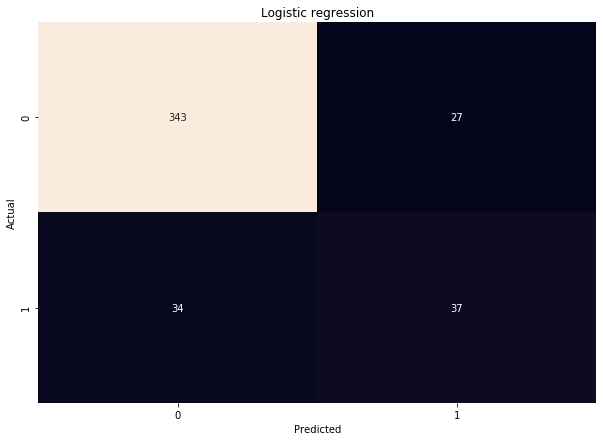

```
[None, None]
```

```python
# visualization using confusion matrix
confusionmatrix(y_test,logreg.predict(X_test),x='Logistic regression')
```

## SVM (SUPPORT VECTOR MACHINE )

### Performing grid search

```python
from sklearn.svm import SVC
# defining parameter range
param_grid = [{'C': [0.1, 1, 10, 100, 1000],
              'gamma': [1, 0.1, 0.01, 0.001, 0.0001],
              'kernel': ['rbf']},{'C': [0.1, 1, 10, 100, 1000],
              'gamma': [1, 0.1, 0.01, 0.001, 0.0001],
              'kernel': ['linear']}]
svc = SVC()
svc_cv = GridSearchCV(svc, param_grid, scoring='accuracy', cv=10,n_jobs=-1)
svc_cv.fit(X_train,y_train)

print("tuned hpyerparameters :(best parameters) ",svc_cv.best_params_)
print("accuracy :",svc_cv.best_score_)
```

```
tuned hpyerparameters :(best parameters)  {'C': 10, 'gamma': 0.1, 'kernel': 'rbf'}
accuracy : 0.8986754966887418
```

```python
svc = SVC(C= 10, gamma= 0.1, kernel= 'rbf')
svc.fit(X_train, y_train)
```

```
SVC(C=10, gamma=0.1)
```

```python
svm_train_acc=svc.score(X_train,y_train)
svm_test_acc=svc.score(X_test,y_test)

print('Train accuracy for SVM:', svc.score(X_train,y_train))
print('Test accuracy for SVM :', svc.score(X_test,y_test))
```

```
Train accuracy for SVM: 1.0
Test accuracy for SVM : 0.8344671201814059
```

```python
y_pred_svm = svc.predict(X_test)
```

```python
print(metrics.classification_report(y_test,y_pred_svm))
```

```
              precision    recall  f1-score   support

           0       0.84      0.99      0.91       370
           1       0.33      0.03      0.05        71

    accuracy                           0.83       441
   macro avg       0.59      0.51      0.48       441
weighted avg       0.76      0.83      0.77       441
```

### Storing information for ROC CURVE

```python
from sklearn.metrics import roc_auc_score
from sklearn.metrics import roc_curve
roc_auc_svm_reg=roc_auc_score(y_test,svc.predict(X_test))
fpr2,tpr2,thresholds=roc_curve(y_test,svc.predict(X_test))
```

```
50.87
```

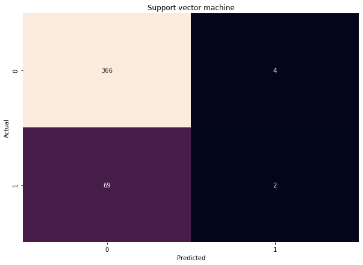

```
[None, None]
```

```python
# visualization using confusion matrix
confusionmatrix(y_test,svc.predict(X_test),x='Support vector machine')
```

## Random Forest

```python
from sklearn.model_selection import RandomizedSearchCV
def hypertuning_rscv(est,p_distr,nbr_iter,X,y):
    rdmsearch=RandomizedSearchCV(est,param_distributions=p_distr,n_jobs=-1,n_iter=nbr_iter,cv=9)
    rdmsearch.fit(X,y)
    ht_params=rdmsearch.best_params_
    ht_score=rdmsearch.best_score_
    return ht_params, ht_score
```

```python
from sklearn.ensemble import RandomForestClassifier
from scipy.stats import randint
est =RandomForestClassifier(n_jobs=-1)
rf_p_dist={'max_depth':[3,5,10,None],
              'n_estimators':[10,100,200,300,400,500],
               'criterion':['gini','entropy'],
               'bootstrap':[True,False],
              }
rf_parameters,rf_ht_score=hypertuning_rscv(est,rf_p_dist,40,X_train,y_train)

print(rf_parameters)
print(rf_ht_score)
```

```
{'n_estimators': 200, 'max_depth': None, 'criterion': 'gini', 'bootstrap': False}
0.9239101162753857
```

```python
clf=RandomForestClassifier(n_estimators= 200, max_depth= None, criterion= 'gini', bootstrap= False)
clf.fit(X_train,y_train)
```

```
RandomForestClassifier(bootstrap=False, n_estimators=200)
```

```python
random_train_acc=clf.score(X_train,y_train)
random_test_acc=clf.score(X_test,y_test)
print('Train accuracy for Random Forest:', clf.score(X_train,y_train))
print('Test accuracy for Random Forest :', clf.score(X_test,y_test))
```

```
Train accuracy for Random Forest: 1.0
Test accuracy for Random Forest : 0.8616780045351474
```

```python
y_pred_rnd = clf.predict(X_test)
```

```python
print(metrics.classification_report(y_test,y_pred_rnd))
```

```
              precision    recall  f1-score   support

           0       0.87      0.98      0.92       370
           1       0.68      0.27      0.38        71

    accuracy                           0.86       441
   macro avg       0.78      0.62      0.65       441
weighted avg       0.84      0.86      0.84       441
```

### Storing information for ROC CURVE

```python
from sklearn.metrics import roc_auc_score
from sklearn.metrics import roc_curve
roc_auc_rnd_reg=roc_auc_score(y_test,clf.predict(X_test))
fpr3,tpr3,thresholds=roc_curve(y_test,clf.predict(X_test))
```

```
62.16
```

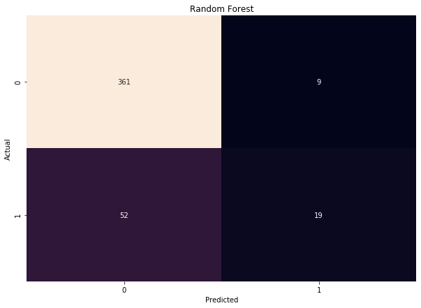

```
[None, None]
```

```python
# visualization using confusion matrix
confusionmatrix(y_test,clf.predict(X_test),x='Random Forest')
```

# K-NN Method

```python
from sklearn.neighbors import KNeighborsClassifier
acc_train_knn_classifier= np.empty((10, 1))
acc_test_knn_classifier= np.empty((10, 1))

for i in range(0,10):
      knn = KNeighborsClassifier(n_neighbors=i+1)
      knn.fit(X_train,y_train)
      acc_knn_classifier[i,:]=round(knn.score(X_train,y_train) * 100, 2)
      acc_test_knn_classifier[i,:]= round(knn.score(X_test,y_test) * 100, 2)

acc_test_knn_classifier
```

```
array([[75.96],
       [80.95],
       [78.46],
       [80.27],
       [77.55],
       [80.95],
       [78.68],
       [81.18],
       [79.82],
       [81.18]])
```

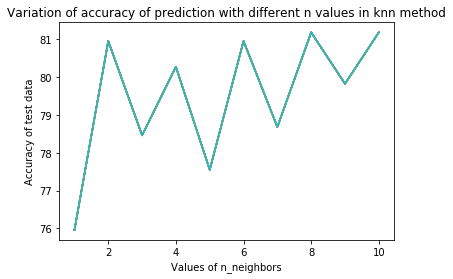

```python
plt.figure()
l = range(1,11)
for j in range(len(l)):
    plt.plot( l, acc_test_knn_classifier)
    plt.xlabel('Values of n_neighbors')
    plt.ylabel('Accuracy of test data')
    plt.title('Variation of accuracy of prediction with different n values in knn method')
```

```python
maxElement = np.amax(acc_test_knn_classifier)
result = np.where(acc_test_knn_classifier == np.amax(acc_test_knn_classifier))
max_accuracy_index=result[0]+1

max_accuracy_index
```

```
array([ 8, 10], dtype=int64)
```

```
59.19
```

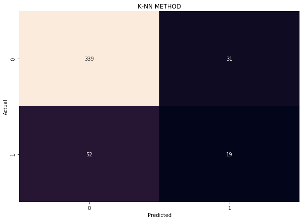

```
[None, None]
```

```python
#visualization using confusion matrix for maximum accuracy as it comes at n_neighbors
knn =KNeighborsClassifier(n_neighbors=max_accuracy_index[0])
knn.fit(X_train,y_train)
# visualization using confusion matrix
confusionmatrix(y_test,knn.predict(X_test),x='K-NN METHOD')
```

```python
y_pred_knn = knn.predict(X_test)
```

```python
print(metrics.classification_report(y_test,y_pred_knn))
```

```
              precision    recall  f1-score   support

           0       0.87      0.92      0.89       370
           1       0.38      0.27      0.31        71

    accuracy                           0.81       441
   macro avg       0.62      0.59      0.60       441
weighted avg       0.79      0.81      0.80       441
```

### Storing information for ROC CURVE

```python
from sklearn.metrics import roc_auc_score
from sklearn.metrics import roc_curve
roc_auc_KNN_reg=roc_auc_score(y_test,knn.predict(X_test))
fpr4,tpr4,thresholds=roc_curve(y_test,knn.predict(X_test))
```

## Plotting roc curves

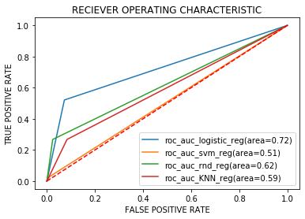

```python
import matplotlib.pyplot as plt
plt.figure()
plt.plot(fpr1,tpr1,Label="roc_auc_logistic_reg(area=%0.2f)" % roc_auc_logistic_reg )
plt.plot(fpr2,tpr2,Label="roc_auc_svm_reg(area=%0.2f)" % roc_auc_svm_reg )
plt.plot(fpr3,tpr3,Label="roc_auc_rnd_reg(area=%0.2f)" % roc_auc_rnd_reg )
plt.plot(fpr4,tpr4,Label="roc_auc_KNN_reg(area=%0.2f)" % roc_auc_KNN_reg )
plt.plot([0,1],[0,1],'r--')
plt.xlabel('FALSE POSITIVE RATE')
plt.ylabel('TRUE POSITIVE RATE')
plt.title('RECIEVER OPERATING CHARACTERISTIC')
plt.legend(loc="lower right")
plt.show()
```

# Models evaluation

```python
##Models evaluation
models = pd.DataFrame({
    'Model': ['Logistic Regression', 'Support Vector Machines', 'Random Forest','KNN CLASSIFIER'],
    'Score_train': [logreg_train_acc, svm_train_acc,random_train_acc, acc_train_knn_classifier[9]],
    'Score_test': [logreg_test_acc, svm_test_acc,random_test_acc, acc_test_knn_classifier[9]]})

models['Score_diff'] = abs(models['Score_train'] - models['Score_test'])
models.sort_values(by=['Score_diff'], ascending=True)
models
```

|  | Model | Score_train | Score_test | Score_diff |
| --- | --- | --- | --- | --- |
| 0 | Logistic Regression | 0.909272 | 0.861678 | 0.0475935 |
| 1 | Support Vector Machines | 1 | 0.834467 | 0.165533 |
| 2 | Random Forest | 1 | 0.861678 | 0.138322 |
| 3 | KNN CLASSIFIER | [20.0] | [81.18] | [61.18000000000001] |

# Models evaluation plot

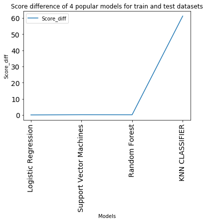

```python
plt.figure()
xx = models['Model']
plt.tick_params(labelsize=14)
plt.plot(xx, models['Score_diff'], label = 'Score_diff')
plt.legend()
plt.title('Score difference of 4 popular models for train and test datasets')
plt.xlabel('Models')
plt.ylabel('Score_diff')
plt.xticks(xx, rotation='vertical')
plt.show()
```